# ADA PROJECT

## Visualize distribution Bar Graphs & Charts

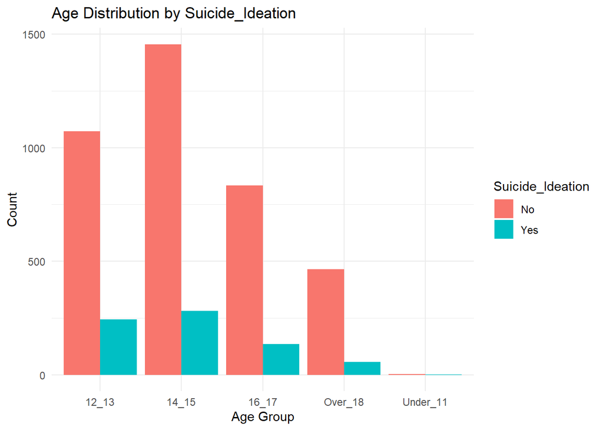

```r
library(ggplot2)
library(dplyr)
## distribution by Age
# Create a  Age data frame
data <- data.frame(
  Category = c("Under_11", "12_13", "14_15", "16_17", "Over_18"),
  No = c(3, 1072, 1456, 833, 464),
  Yes = c(1, 244, 282, 135, 57)
)

# Reshape data for plotting
data_long <- data %>%
  gather(key = "Suicide_Ideation", value = "Count", -Category)

# Plot
ggplot(data_long, aes(x = Category, y = Count, fill = Suicide_Ideation)) +
  geom_bar(stat = "identity", position = "dodge") +
  labs(title = "Age Distribution by Suicide_Ideation", x = "Age Group", y = "Count") +
  theme_minimal()
```

# Interpretations The age distribution reveals a higher concentration of participants in the 12_13 and 14_15 age groups, with 28.9% and 38.2% of the total sample, respectively. The 16_17 and Over_18 groups represent a smaller percentage (21.3% and 11.5%, respectively). The Yes group tends to be slightly younger, with a higher proportion in the 12_13 and 14_15 categories

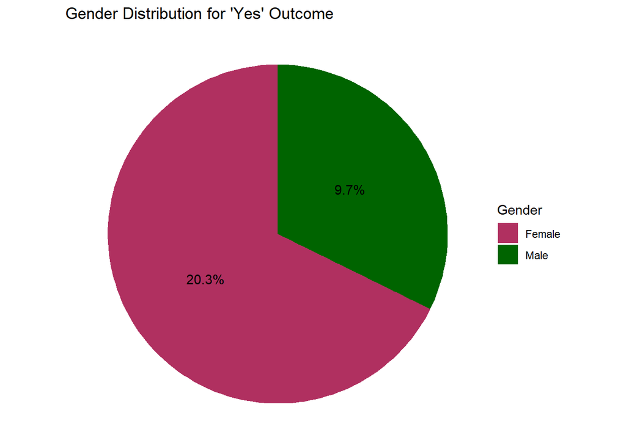

```r
## Distribution by Gender

# Create the data for gender and 'Yes' outcome (from your table example)
gender_data <- data.frame(
  Gender = c("Female", "Male"),
  Yes = c(534, 185),
  Total = c(2634, 1913)
)

# Calculate the percentage of "Yes" for each gender
gender_data$Percentage <- gender_data$Yes / gender_data$Total * 100

# Plot the pie chart
ggplot(gender_data, aes(x = "", y = Percentage, fill = Gender)) +
  geom_bar(stat = "identity", width = 1) +
  coord_polar(theta = "y") +
  geom_text(aes(label = paste0(round(Percentage, 1), "%")), position = position_stack(vjust = 0.5)) +
  labs(title = "Gender Distribution for 'Yes' Outcome") +
  theme_void() +
  scale_fill_manual(values = c("maroon", "darkgreen"))
```

#Interepretations Females make up a larger proportion of the Yes group (74.3%) compared to males (25.7%). Overall, females represent 57.9% of the total sample. This indicates that females in this dataset may have higher rates of experiencing the outcome compared to males, suggesting a gender-based difference in mental health or behavior outcomes.

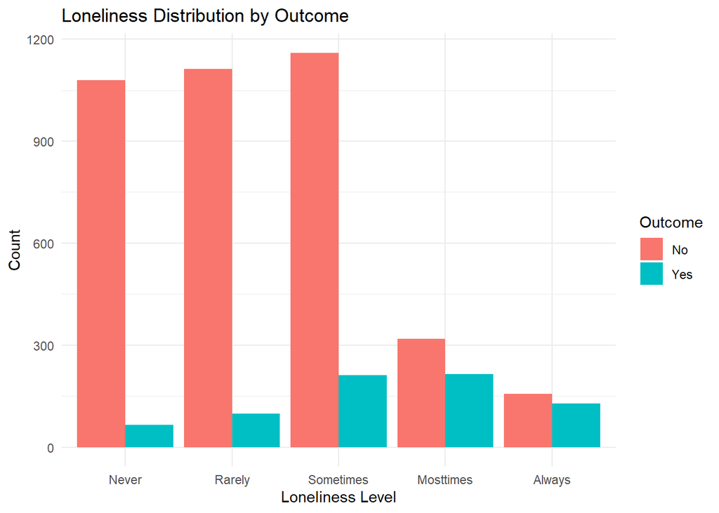

```r
# Loneliness data example
loneliness_data <- data.frame(
  Loneliness = c("Never", "Rarely", "Sometimes", "Mosttimes", "Always"),
  No = c(1080, 1112, 1160, 319, 157),
  Yes = c(66, 98, 212, 215, 128)
)

# Reshape data for plotting
loneliness_data_long <- loneliness_data %>%
  gather(key = "Outcome", value = "Count", -Loneliness)
# Set the factor levels for the Loneliness variable in the desired order
loneliness_data_long$Loneliness <- factor(loneliness_data_long$Loneliness,
                                          levels = c("Never", "Rarely", "Sometimes", "Mosttimes", "Always"))

# Plot
ggplot(loneliness_data_long, aes(x = Loneliness, y = Count, fill = Outcome)) +
  geom_bar(stat = "identity", position = "dodge") +
  labs(title = "Loneliness Distribution by Outcome", x = "Loneliness Level", y = "Count") +
  theme_minimal()
```

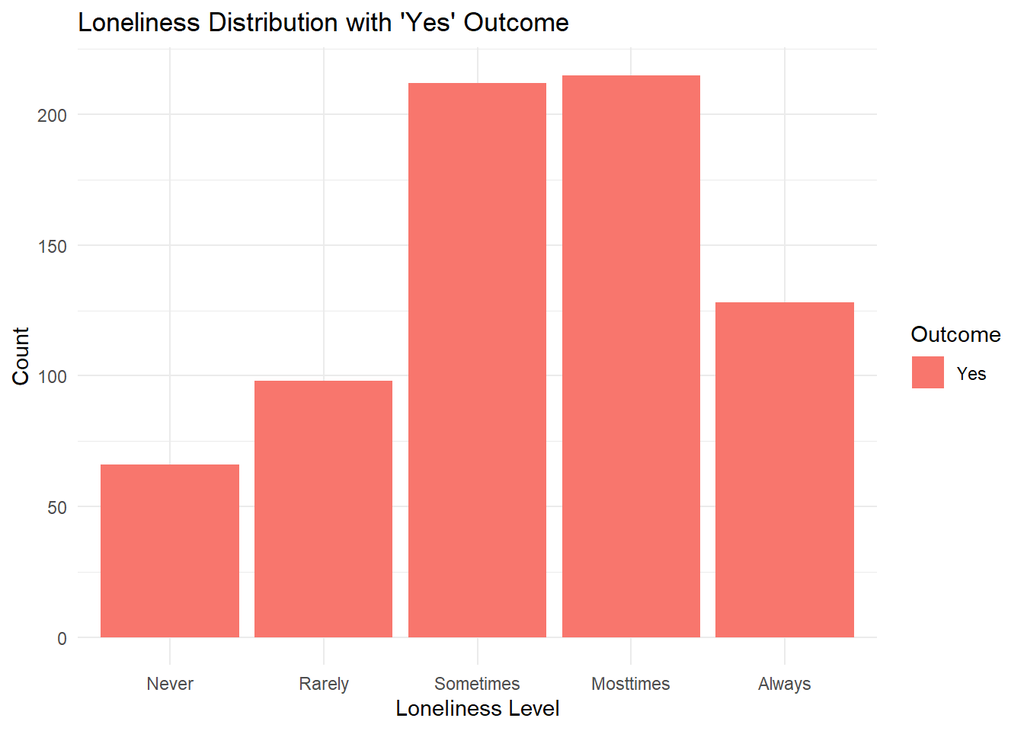

```r
# Reshape data for plotting, focusing on the 'Yes' outcome
loneliness_data_long <- loneliness_data %>%
  gather(key = "Outcome", value = "Count", -Loneliness) %>%
  filter(Outcome == "Yes")  # Filter to include only 'Yes' outcome

# Set the factor levels for the Loneliness variable in the desired order
loneliness_data_long$Loneliness <- factor(loneliness_data_long$Loneliness,
                                          levels = c("Never", "Rarely", "Sometimes", "Mosttimes", "Always"))


# Plot_2
ggplot(loneliness_data_long, aes(x = Loneliness, y = Count, fill = Outcome)) +
  geom_bar(stat = "identity", position = "dodge") +
  labs(title = "Loneliness Distribution with 'Yes' Outcome", x = "Loneliness Level", y = "Count") +
  theme_minimal()
```

#interpretations The data on loneliness shows that those who answered “Yes” report higher levels of loneliness, particularly in the Mosttimes and Always categories, which account for 29.9% and 17.8%, respectively. In contrast, the No group primarily reports lower levels of loneliness, particularly in the Never and Rarely categories (28.2% and 29.0%, respectively).

##Model 1 Total Effect

```r
# Recode 'Yes' and 'No' to 1 and 0
Thai_R_Final $suicide <- ifelse(Thai_R_Final$Suicide == "Yes", 1, 0)


#Perform a general linear model
model_1 <- glm (Suicide ~ Loneliness + Age + Gender + Number_of_friends +  Parental_support,
             family = binomial(link = "logit"), data = Thai_R_Final)

summary(model_1)
```

```
##
## Call:
## glm(formula = Suicide ~ Loneliness + Age + Gender + Number_of_friends +
##     Parental_support, family = binomial(link = "logit"), data = Thai_R_Final)
##
## Coefficients:
##                           Estimate Std. Error z value Pr(>|z|)
## (Intercept)               -1.76917    0.22669  -7.804 5.99e-15 ***
## LonelinessRarely           0.34029    0.16724   2.035 0.041880 *
## LonelinessSometimes        0.97949    0.14981   6.538 6.23e-11 ***
## LonelinessMosttimes        2.25308    0.15819  14.243  < 2e-16 ***
## LonelinessAlways           2.36697    0.17954  13.184  < 2e-16 ***
## Age14_15                  -0.25390    0.10543  -2.408 0.016032 *
## Age16_17                  -0.38135    0.12737  -2.994 0.002753 **
## AgeOver_18                -0.60609    0.16935  -3.579 0.000345 ***
## GenderMale                -0.77744    0.09804  -7.930 2.19e-15 ***
## Number_of_friends1         0.19095    0.21678   0.881 0.378382
## Number_of_friends2         0.01810    0.21344   0.085 0.932421
## Number_of_friends>3       -0.14443    0.17115  -0.844 0.398729
## Parental_supportRarely    -0.21641    0.12398  -1.746 0.080887 .
## Parental_supportSometimes -0.46189    0.11808  -3.912 9.16e-05 ***
## Parental_supportMosttimes -0.80761    0.16026  -5.039 4.67e-07 ***
## Parental_supportAlways    -0.72017    0.15820  -4.552 5.31e-06 ***
## ---
## Signif. codes:  0 '***' 0.001 '**' 0.01 '*' 0.05 '.' 0.1 ' ' 1
##
## (Dispersion parameter for binomial family taken to be 1)
##
##     Null deviance: 3970.0  on 4546  degrees of freedom
## Residual deviance: 3346.4  on 4531  degrees of freedom
## AIC: 3378.4
##
## Number of Fisher Scoring iterations: 5
```

```r
#confidence intervals
broom::tidy(model_1, exponentiate = TRUE, conf.int = TRUE)
```

```
## # A tibble: 16 × 7
##    term                 estimate std.error statistic  p.value conf.low conf.high
##    <chr>                   <dbl>     <dbl>     <dbl>    <dbl>    <dbl>     <dbl>
##  1 (Intercept)             0.170    0.227    -7.80   5.99e-15    0.109     0.264
##  2 LonelinessRarely        1.41     0.167     2.03   4.19e- 2    1.01      1.96
##  3 LonelinessSometimes     2.66     0.150     6.54   6.23e-11    2.00      3.59
##  4 LonelinessMosttimes     9.52     0.158    14.2    4.99e-46    7.02     13.1
##  5 LonelinessAlways       10.7      0.180    13.2    1.09e-39    7.53     15.2
##  6 Age14_15                0.776    0.105    -2.41   1.60e- 2    0.631     0.954
##  7 Age16_17                0.683    0.127    -2.99   2.75e- 3    0.531     0.875
##  8 AgeOver_18              0.545    0.169    -3.58   3.45e- 4    0.389     0.755
##  9 GenderMale              0.460    0.0980   -7.93   2.19e-15    0.379     0.556
## 10 Number_of_friends1      1.21     0.217     0.881  3.78e- 1    0.792     1.85
## 11 Number_of_friends2      1.02     0.213     0.0848 9.32e- 1    0.671     1.55
## 12 Number_of_friends>3     0.866    0.171    -0.844  3.99e- 1    0.622     1.22
## 13 Parental_supportRar…    0.805    0.124    -1.75   8.09e- 2    0.631     1.03
## 14 Parental_supportSom…    0.630    0.118    -3.91   9.16e- 5    0.499     0.793
## 15 Parental_supportMos…    0.446    0.160    -5.04   4.67e- 7    0.324     0.607
## 16 Parental_supportAlw…    0.487    0.158    -4.55   5.31e- 6    0.355     0.660
```

```r
 #Tidy the model and round specific columns to 2 decimal places
broom::tidy(model_1, exponentiate = TRUE, conf.int = TRUE) %>%
  mutate(
    estimate = round(estimate, 2),
    std.error = round(std.error, 2),
    statistic = round(statistic, 2),
    conf.low = round(conf.low, 2),
    conf.high = round(conf.high, 2)
  )
```

```
## # A tibble: 16 × 7
##    term                 estimate std.error statistic  p.value conf.low conf.high
##    <chr>                   <dbl>     <dbl>     <dbl>    <dbl>    <dbl>     <dbl>
##  1 (Intercept)              0.17      0.23     -7.8  5.99e-15     0.11      0.26
##  2 LonelinessRarely         1.41      0.17      2.03 4.19e- 2     1.01      1.96
##  3 LonelinessSometimes      2.66      0.15      6.54 6.23e-11     2         3.59
##  4 LonelinessMosttimes      9.52      0.16     14.2  4.99e-46     7.02     13.0
##  5 LonelinessAlways        10.7       0.18     13.2  1.09e-39     7.53     15.2
##  6 Age14_15                 0.78      0.11     -2.41 1.60e- 2     0.63      0.95
##  7 Age16_17                 0.68      0.13     -2.99 2.75e- 3     0.53      0.88
##  8 AgeOver_18               0.55      0.17     -3.58 3.45e- 4     0.39      0.76
##  9 GenderMale               0.46      0.1      -7.93 2.19e-15     0.38      0.56
## 10 Number_of_friends1       1.21      0.22      0.88 3.78e- 1     0.79      1.85
## 11 Number_of_friends2       1.02      0.21      0.08 9.32e- 1     0.67      1.55
## 12 Number_of_friends>3      0.87      0.17     -0.84 3.99e- 1     0.62      1.22
## 13 Parental_supportRar…     0.81      0.12     -1.75 8.09e- 2     0.63      1.03
## 14 Parental_supportSom…     0.63      0.12     -3.91 9.16e- 5     0.5       0.79
## 15 Parental_supportMos…     0.45      0.16     -5.04 4.67e- 7     0.32      0.61
## 16 Parental_supportAlw…     0.49      0.16     -4.55 5.31e- 6     0.35      0.66
```

##Model 2 Direct effect

```r
# Recode 'Yes' and 'No' to 1 and 0
Thai_R_Final $suicide <- ifelse(Thai_R_Final$Suicide == "Yes", 1, 0)


#Perform a general linear model
model_2 <- glm (Suicide ~ Loneliness + Age + Gender + Number_of_friends +  Parental_support + Alcohol + Drug_use,
             family = binomial(link = "logit"), data = Thai_R_Final)

summary(model_2)
```

```
##
## Call:
## glm(formula = Suicide ~ Loneliness + Age + Gender + Number_of_friends +
##     Parental_support + Alcohol + Drug_use, family = binomial(link = "logit"),
##     data = Thai_R_Final)
##
## Coefficients:
##                           Estimate Std. Error z value Pr(>|z|)
## (Intercept)               -1.99620    0.23140  -8.626  < 2e-16 ***
## LonelinessRarely           0.30475    0.16788   1.815 0.069481 .
## LonelinessSometimes        0.91474    0.15078   6.067 1.31e-09 ***
## LonelinessMosttimes        2.19142    0.15918  13.767  < 2e-16 ***
## LonelinessAlways           2.30718    0.18141  12.718  < 2e-16 ***
## Age14_15                  -0.37715    0.10793  -3.494 0.000475 ***
## Age16_17                  -0.51260    0.13021  -3.937 8.26e-05 ***
## AgeOver_18                -0.87690    0.17434  -5.030 4.91e-07 ***
## GenderMale                -0.79511    0.10085  -7.884 3.16e-15 ***
## Number_of_friends1         0.24642    0.21977   1.121 0.262187
## Number_of_friends2         0.01866    0.21592   0.086 0.931131
## Number_of_friends>3       -0.14016    0.17334  -0.809 0.418762
## Parental_supportRarely    -0.22090    0.12522  -1.764 0.077719 .
## Parental_supportSometimes -0.41986    0.11921  -3.522 0.000428 ***
## Parental_supportMosttimes -0.73714    0.16195  -4.552 5.32e-06 ***
## Parental_supportAlways    -0.67727    0.15905  -4.258 2.06e-05 ***
## AlcoholYes                 0.63718    0.09486   6.717 1.86e-11 ***
## Drug_useYes                0.33765    0.15966   2.115 0.034448 *
## ---
## Signif. codes:  0 '***' 0.001 '**' 0.01 '*' 0.05 '.' 0.1 ' ' 1
##
## (Dispersion parameter for binomial family taken to be 1)
##
##     Null deviance: 3970.0  on 4546  degrees of freedom
## Residual deviance: 3288.3  on 4529  degrees of freedom
## AIC: 3324.3
##
## Number of Fisher Scoring iterations: 5
```

```r
broom::tidy(model_2, exponentiate = TRUE, conf.int = TRUE)
```

```
## # A tibble: 18 × 7
##    term                 estimate std.error statistic  p.value conf.low conf.high
##    <chr>                   <dbl>     <dbl>     <dbl>    <dbl>    <dbl>     <dbl>
##  1 (Intercept)             0.136    0.231    -8.63   6.33e-18   0.0857     0.212
##  2 LonelinessRarely        1.36     0.168     1.82   6.95e- 2   0.978      1.89
##  3 LonelinessSometimes     2.50     0.151     6.07   1.31e- 9   1.87       3.38
##  4 LonelinessMosttimes     8.95     0.159    13.8    4.03e-43   6.58      12.3
##  5 LonelinessAlways       10.0      0.181    12.7    4.69e-37   7.07      14.4
##  6 Age14_15                0.686    0.108    -3.49   4.75e- 4   0.555      0.847
##  7 Age16_17                0.599    0.130    -3.94   8.26e- 5   0.463      0.772
##  8 AgeOver_18              0.416    0.174    -5.03   4.91e- 7   0.294      0.582
##  9 GenderMale              0.452    0.101    -7.88   3.16e-15   0.370      0.549
## 10 Number_of_friends1      1.28     0.220     1.12   2.62e- 1   0.833      1.97
## 11 Number_of_friends2      1.02     0.216     0.0864 9.31e- 1   0.668      1.56
## 12 Number_of_friends>3     0.869    0.173    -0.809  4.19e- 1   0.622      1.23
## 13 Parental_supportRar…    0.802    0.125    -1.76   7.77e- 2   0.626      1.02
## 14 Parental_supportSom…    0.657    0.119    -3.52   4.28e- 4   0.520      0.829
## 15 Parental_supportMos…    0.478    0.162    -4.55   5.32e- 6   0.346      0.654
## 16 Parental_supportAlw…    0.508    0.159    -4.26   2.06e- 5   0.370      0.690
## 17 AlcoholYes              1.89     0.0949    6.72   1.86e-11   1.57       2.28
## 18 Drug_useYes             1.40     0.160     2.11   3.44e- 2   1.02       1.91
```

```r
 #Tidy the model and round specific columns to 2 decimal places
broom::tidy(model_2, exponentiate = TRUE, conf.int = TRUE) %>%
  mutate(
    estimate = round(estimate, 2),
    std.error = round(std.error, 2),
    statistic = round(statistic, 2),
    conf.low = round(conf.low, 2),
    conf.high = round(conf.high, 2)
  )
```

```
## # A tibble: 18 × 7
##    term                 estimate std.error statistic  p.value conf.low conf.high
##    <chr>                   <dbl>     <dbl>     <dbl>    <dbl>    <dbl>     <dbl>
##  1 (Intercept)              0.14      0.23     -8.63 6.33e-18     0.09      0.21
##  2 LonelinessRarely         1.36      0.17      1.82 6.95e- 2     0.98      1.89
##  3 LonelinessSometimes      2.5       0.15      6.07 1.31e- 9     1.87      3.38
##  4 LonelinessMosttimes      8.95      0.16     13.8  4.03e-43     6.58     12.3
##  5 LonelinessAlways        10.0       0.18     12.7  4.69e-37     7.07     14.4
##  6 Age14_15                 0.69      0.11     -3.49 4.75e- 4     0.55      0.85
##  7 Age16_17                 0.6       0.13     -3.94 8.26e- 5     0.46      0.77
##  8 AgeOver_18               0.42      0.17     -5.03 4.91e- 7     0.29      0.58
##  9 GenderMale               0.45      0.1      -7.88 3.16e-15     0.37      0.55
## 10 Number_of_friends1       1.28      0.22      1.12 2.62e- 1     0.83      1.97
## 11 Number_of_friends2       1.02      0.22      0.09 9.31e- 1     0.67      1.56
## 12 Number_of_friends>3      0.87      0.17     -0.81 4.19e- 1     0.62      1.23
## 13 Parental_supportRar…     0.8       0.13     -1.76 7.77e- 2     0.63      1.02
## 14 Parental_supportSom…     0.66      0.12     -3.52 4.28e- 4     0.52      0.83
## 15 Parental_supportMos…     0.48      0.16     -4.55 5.32e- 6     0.35      0.65
## 16 Parental_supportAlw…     0.51      0.16     -4.26 2.06e- 5     0.37      0.69
## 17 AlcoholYes               1.89      0.09      6.72 1.86e-11     1.57      2.28
## 18 Drug_useYes              1.4       0.16      2.11 3.44e- 2     1.02      1.91
```